# Prosper Loan Data Analysis

## by Mohammed Elshafei

> This data set contains information on peer to peer loans facilitated by credit company Prosper. The data set contains 113,937 loans with 81 variables on each loan, including loan amount, borrower rate (or interest rate), current loan status, borrower income, and many others.

```python
# import all packages and set plots to be embedded inline
import numpy as np
import pandas as pd
import matplotlib.pyplot as plt
import seaborn as sb

%matplotlib inline
```

```python
#Read the data into a pandas dataframe df
df = pd.read_csv('prosperLoanData.csv')
```

```python
#Check the dataframe
df.head()
```

|  | ListingKey | ListingNumber | ListingCreationDate | CreditGrade | Term | LoanStatus | ClosedDate | BorrowerAPR | BorrowerRate | LenderYield | ... | LP_ServiceFees | LP_CollectionFees | LP_GrossPrincipalLoss | LP_NetPrincipalLoss | LP_NonPrincipalRecoverypayments | PercentFunded | Recommendations | InvestmentFromFriendsCount | InvestmentFromFriendsAmount | Investors |
| --- | --- | --- | --- | --- | --- | --- | --- | --- | --- | --- | --- | --- | --- | --- | --- | --- | --- | --- | --- | --- | --- |
| 0 | 1021339766868145413AB3B | 193129 | 2007-08-26 19:09:29.263000000 | C | 36 | Completed | 2009-08-14 00:00:00 | 0.16516 | 0.1580 | 0.1380 | ... | -133.18 | 0.0 | 0.0 | 0.0 | 0.0 | 1.0 | 0 | 0 | 0.0 | 258 |
| 1 | 10273602499503308B223C1 | 1209647 | 2014-02-27 08:28:07.900000000 | NaN | 36 | Current | NaN | 0.12016 | 0.0920 | 0.0820 | ... | 0.00 | 0.0 | 0.0 | 0.0 | 0.0 | 1.0 | 0 | 0 | 0.0 | 1 |
| 2 | 0EE9337825851032864889A | 81716 | 2007-01-05 15:00:47.090000000 | HR | 36 | Completed | 2009-12-17 00:00:00 | 0.28269 | 0.2750 | 0.2400 | ... | -24.20 | 0.0 | 0.0 | 0.0 | 0.0 | 1.0 | 0 | 0 | 0.0 | 41 |
| 3 | 0EF5356002482715299901A | 658116 | 2012-10-22 11:02:35.010000000 | NaN | 36 | Current | NaN | 0.12528 | 0.0974 | 0.0874 | ... | -108.01 | 0.0 | 0.0 | 0.0 | 0.0 | 1.0 | 0 | 0 | 0.0 | 158 |
| 4 | 0F023589499656230C5E3E2 | 909464 | 2013-09-14 18:38:39.097000000 | NaN | 36 | Current | NaN | 0.24614 | 0.2085 | 0.1985 | ... | -60.27 | 0.0 | 0.0 | 0.0 | 0.0 | 1.0 | 0 | 0 | 0.0 | 20 |

5 rows × 81 columns

```python
#Get the shape of the dataframe
df.shape
```

```
(113937, 81)
```

```python
#Get info on the dataframe
df.info()
```

```
<class 'pandas.core.frame.DataFrame'>
RangeIndex: 113937 entries, 0 to 113936
Data columns (total 81 columns):
 #   Column                               Non-Null Count   Dtype
---  ------                               --------------   -----
 0   ListingKey                           113937 non-null  object
 1   ListingNumber                        113937 non-null  int64
 2   ListingCreationDate                  113937 non-null  object
 3   CreditGrade                          28953 non-null   object
 4   Term                                 113937 non-null  int64
 5   LoanStatus                           113937 non-null  object
 6   ClosedDate                           55089 non-null   object
 7   BorrowerAPR                          113912 non-null  float64
 8   BorrowerRate                         113937 non-null  float64
 9   LenderYield                          113937 non-null  float64
```

[output cut: 73 more lines]

> As we can see, the dataset contains 81 columns which will be complex to analyize all of this data. So, for the purpose of this analysis we will look into the following variables:
> - Term
> - LoanStatus
> - BorrowerRate
> - ProsperRating (Alpha)
> - ListingCategory (numeric)
> - EmploymentStatus
> - CreditScoreRangeLower
> - CreditScoreRangeUpper
> - TotalProsperLoans
> - LoanOriginationDate
> - ProsperScore

> First, we need fo perform some data wrangling

```python
#identify required columns for analysis
required_columns =  [
    'Term', 'LoanStatus', 'BorrowerRate', 'ProsperRating (Alpha)', 'ListingCategory (numeric)', 'EmploymentStatus',
    'TotalProsperLoans', 'LoanOriginalAmount',
    'LoanOriginationDate', 'CreditScoreRangeLower', 'CreditScoreRangeUpper', 'ProsperScore'
]
```

```python
#Create new dataframe with required columns for analysis
analysis_df = df[required_columns]

#show dataframe
analysis_df.head()
```

|  | Term | LoanStatus | BorrowerRate | ProsperRating (Alpha) | ListingCategory (numeric) | EmploymentStatus | TotalProsperLoans | LoanOriginalAmount | LoanOriginationDate | CreditScoreRangeLower | CreditScoreRangeUpper | ProsperScore |
| --- | --- | --- | --- | --- | --- | --- | --- | --- | --- | --- | --- | --- |
| 0 | 36 | Completed | 0.1580 | NaN | 0 | Self-employed | NaN | 9425 | 2007-09-12 00:00:00 | 640.0 | 659.0 | NaN |
| 1 | 36 | Current | 0.0920 | A | 2 | Employed | NaN | 10000 | 2014-03-03 00:00:00 | 680.0 | 699.0 | 7.0 |
| 2 | 36 | Completed | 0.2750 | NaN | 0 | Not available | NaN | 3001 | 2007-01-17 00:00:00 | 480.0 | 499.0 | NaN |
| 3 | 36 | Current | 0.0974 | A | 16 | Employed | NaN | 10000 | 2012-11-01 00:00:00 | 800.0 | 819.0 | 9.0 |
| 4 | 36 | Current | 0.2085 | D | 2 | Employed | 1.0 | 15000 | 2013-09-20 00:00:00 | 680.0 | 699.0 | 4.0 |

```python
analysis_df.info()
```

```
<class 'pandas.core.frame.DataFrame'>
RangeIndex: 113937 entries, 0 to 113936
Data columns (total 12 columns):
 #   Column                     Non-Null Count   Dtype
---  ------                     --------------   -----
 0   Term                       113937 non-null  int64
 1   LoanStatus                 113937 non-null  object
 2   BorrowerRate               113937 non-null  float64
 3   ProsperRating (Alpha)      84853 non-null   object
 4   ListingCategory (numeric)  113937 non-null  int64
 5   EmploymentStatus           111682 non-null  object
 6   TotalProsperLoans          22085 non-null   float64
 7   LoanOriginalAmount         113937 non-null  int64
 8   LoanOriginationDate        113937 non-null  object
 9   CreditScoreRangeLower      113346 non-null  float64
 10  CreditScoreRangeUpper      113346 non-null  float64
 11  ProsperScore               84853 non-null   float64
dtypes: float64(5), int64(3), object(4)
memory usage: 10.4+ MB
```

> - We can see alot of null values in the "ProsperRating (Alpha)" columns, this is because Prosper used their own proprietary Prosper Rating only since 2009 as mentioned in the dictionary of this dataset. We will drop these values for our analysis.
> - We will also convert LoanOriginationDate to datetime datatype

```python
#Drop rows will null values in ProsperRating (Alpha)
analysis_df = analysis_df.dropna(subset=['ProsperRating (Alpha)']).reset_index()
analysis_df.info()
```

```
<class 'pandas.core.frame.DataFrame'>
RangeIndex: 84853 entries, 0 to 84852
Data columns (total 13 columns):
 #   Column                     Non-Null Count  Dtype
---  ------                     --------------  -----
 0   index                      84853 non-null  int64
 1   Term                       84853 non-null  int64
 2   LoanStatus                 84853 non-null  object
 3   BorrowerRate               84853 non-null  float64
 4   ProsperRating (Alpha)      84853 non-null  object
 5   ListingCategory (numeric)  84853 non-null  int64
 6   EmploymentStatus           84853 non-null  object
 7   TotalProsperLoans          19797 non-null  float64
 8   LoanOriginalAmount         84853 non-null  int64
 9   LoanOriginationDate        84853 non-null  object
 10  CreditScoreRangeLower      84853 non-null  float64
 11  CreditScoreRangeUpper      84853 non-null  float64
 12  ProsperScore               84853 non-null  float64
dtypes: float64(5), int64(4), object(4)
memory usage: 8.4+ MB
```

```python
#Change LoanOriginationDate to datetime format
analysis_df['LoanOriginationDate'] = pd.to_datetime(analysis_df['LoanOriginationDate'])
analysis_df.info()
```

```
<class 'pandas.core.frame.DataFrame'>
RangeIndex: 84853 entries, 0 to 84852
Data columns (total 13 columns):
 #   Column                     Non-Null Count  Dtype
---  ------                     --------------  -----
 0   index                      84853 non-null  int64
 1   Term                       84853 non-null  int64
 2   LoanStatus                 84853 non-null  object
 3   BorrowerRate               84853 non-null  float64
 4   ProsperRating (Alpha)      84853 non-null  object
 5   ListingCategory (numeric)  84853 non-null  int64
 6   EmploymentStatus           84853 non-null  object
 7   TotalProsperLoans          19797 non-null  float64
 8   LoanOriginalAmount         84853 non-null  int64
 9   LoanOriginationDate        84853 non-null  datetime64[ns]
 10  CreditScoreRangeLower      84853 non-null  float64
 11  CreditScoreRangeUpper      84853 non-null  float64
 12  ProsperScore               84853 non-null  float64
dtypes: datetime64[ns](1), float64(5), int64(4), object(3)
memory usage: 8.4+ MB
```

According to the above, we can see that all rows dont have null values, except the TotalProsperLoans. This is because if individual doesn't have previous credit from Prosper, the value is NaN, so we can replace these values with "0".

```python
#fill NAN values in TotalProsperLoans with "0"
analysis_df['TotalProsperLoans'] = analysis_df['TotalProsperLoans'].fillna(0)
analysis_df.info()
```

```
<class 'pandas.core.frame.DataFrame'>
RangeIndex: 84853 entries, 0 to 84852
Data columns (total 13 columns):
 #   Column                     Non-Null Count  Dtype
---  ------                     --------------  -----
 0   index                      84853 non-null  int64
 1   Term                       84853 non-null  int64
 2   LoanStatus                 84853 non-null  object
 3   BorrowerRate               84853 non-null  float64
 4   ProsperRating (Alpha)      84853 non-null  object
 5   ListingCategory (numeric)  84853 non-null  int64
 6   EmploymentStatus           84853 non-null  object
 7   TotalProsperLoans          84853 non-null  float64
 8   LoanOriginalAmount         84853 non-null  int64
 9   LoanOriginationDate        84853 non-null  datetime64[ns]
 10  CreditScoreRangeLower      84853 non-null  float64
 11  CreditScoreRangeUpper      84853 non-null  float64
 12  ProsperScore               84853 non-null  float64
dtypes: datetime64[ns](1), float64(5), int64(4), object(3)
memory usage: 8.4+ MB
```

> - From the above cell, we can see that there are no more missing values and total entires is now 84,853.

### What is the structure of your dataset?

> Following some data wrangling techniques, we reached to 84,853 listings for loan via peer-to-peer credit company Prosper. The variables we have selected are numeric, categorical and datetime types.

### What is/are the main feature(s) of interest in your dataset?

> In this investigation, i will try to know what that factors lead to defaulting on loans.

### What features in the dataset do you think will help support your investigation into your feature(s) of interest?

> I believe that the employment status & credit score will impact the loan status.

## Univariate Exploration

First, Let's look at the term variable.

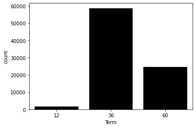

```python
#Plot the Term variable
sb.countplot(data = analysis_df, x = 'Term', color = 'Black')
```

> We can observe that 36 months term loans are most popular / common.

We will look at the Loan status variable.

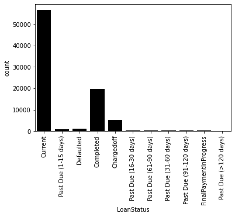

```python
#Plot the LoanStatus variable
plt.xticks(rotation=90)
sb.countplot(data = analysis_df, x = 'LoanStatus', color = 'Black')
```

> - The Majority of listings in the data set are current loans.

We will look in to Borrower Rate.

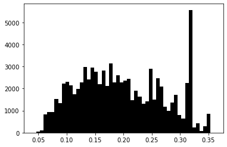

```python
#Plot the Borrower Rate
plt.hist(data=analysis_df, x='BorrowerRate', bins=50, color = 'Black');
```

> - The mode of the borrowers rate disribution is around 0.32.

We will look into the Prosper Rating (Alpha) next.

As we have seen in the dictionary, it appears that ProsperRating (Alpha) is an ordinal categorical variable.

```python
#We will order the variable using pandas

list = ['AA', 'A', 'B', 'C', 'D', 'E', 'HR']


var_orders = pd.api.types.CategoricalDtype(ordered = True,
                                                categories = list)
analysis_df['ProsperRating (Alpha)'] = analysis_df['ProsperRating (Alpha)'].astype(var_orders)
```

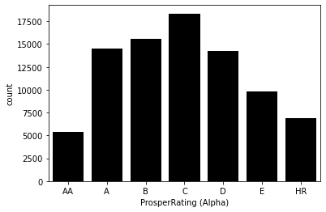

```python
#Plot ProsperRating (Alpha)
sb.countplot(data= analysis_df, x='ProsperRating (Alpha)', color= 'Black')
```

> - We see here that the the ProsperRating (Alpha) is normally distributed.

Now let's look at the purpose of the loan.

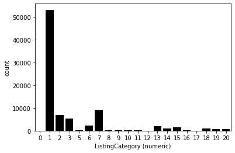

```python
#Plot the ListingCategory (numeric)
sb.countplot(data= analysis_df, x='ListingCategory (numeric)', color= 'Black')
```

```python
analysis_df['ListingCategory (numeric)'].value_counts()
```

```
1     53180
7      9218
2      6801
3      5298
6      2237
13     1996
15     1522
18      885
14      876
20      771
19      768
16      304
5       274
11      217
8       199
10       91
9        85
12       59
17       52
0        20
Name: ListingCategory (numeric), dtype: int64
```

> Below is the interpretation of the numeric values for the loan category:
> - 0 - Not Available,
> - 1 - Debt Consolidation (**Highest**),
> - 2 - Home Improvement,
> - 3 - Business,
> - 4 - Personal Loan,
> - 5 - Student Use,
> - 6 - Auto,
> - 7- Other,
> - 8 - Baby&Adoption,
> - 9 - Boat,
> - 10 - Cosmetic Procedure,
> - 11 - Engagement Ring,
> - 12 - Green Loans,
> - 13 - Household Expenses,
> - 14 - Large Purchases,
> - 15 - Medical/Dental,
> - 16 - Motorcycle,
> - 17 - RV,
> - 18 - Taxes,
> - 19 - Vacation,
> - 20 - Wedding Loans

> The majority of loans are used for debt consolidation reasons.

Now let's look at Employment Status.

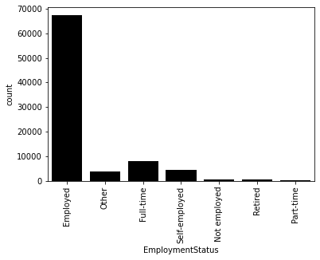

```python
#Plot Employment Status
sb.countplot(data= analysis_df, x='EmploymentStatus', color= 'Black')
plt.xticks(rotation= 90)
```

> - Most of the borrowers are employed.

Next we will look in to TotalProsperLoans.

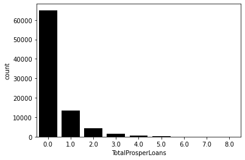

```python
#Plot totalProsper Loans
sb.countplot(data= analysis_df, x='TotalProsperLoans', color= 'Black');
```

> It Looks like most of individuals are their first time taking out a loan.

Let's move on to LoanOriginationDate

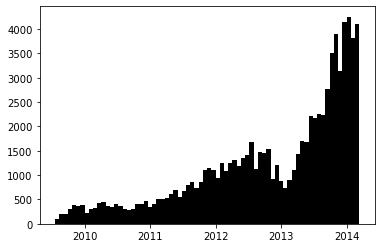

```python
#Plot LoanOriginationDate
plt.hist(data= analysis_df, x='LoanOriginationDate', bins=72, color = 'Black');
```

> There is an upward trend in loans from 2013.

Next we will see the creditscore

```python
#Add a new Feature for average credit score
analysis_df['AverageCreditScore'] = (analysis_df['CreditScoreRangeLower'] + analysis_df['CreditScoreRangeUpper'])/2
analysis_df.head()
```

|  | index | Term | LoanStatus | BorrowerRate | ProsperRating (Alpha) | ListingCategory (numeric) | EmploymentStatus | TotalProsperLoans | LoanOriginalAmount | LoanOriginationDate | CreditScoreRangeLower | CreditScoreRangeUpper | ProsperScore | AverageCreditScore |
| --- | --- | --- | --- | --- | --- | --- | --- | --- | --- | --- | --- | --- | --- | --- |
| 0 | 1 | 36 | Current | 0.0920 | A | 2 | Employed | 0.0 | 10000 | 2014-03-03 | 680.0 | 699.0 | 7.0 | 689.5 |
| 1 | 3 | 36 | Current | 0.0974 | A | 16 | Employed | 0.0 | 10000 | 2012-11-01 | 800.0 | 819.0 | 9.0 | 809.5 |
| 2 | 4 | 36 | Current | 0.2085 | D | 2 | Employed | 1.0 | 15000 | 2013-09-20 | 680.0 | 699.0 | 4.0 | 689.5 |
| 3 | 5 | 60 | Current | 0.1314 | B | 1 | Employed | 0.0 | 15000 | 2013-12-24 | 740.0 | 759.0 | 10.0 | 749.5 |
| 4 | 6 | 36 | Current | 0.2712 | E | 1 | Employed | 0.0 | 3000 | 2013-04-18 | 680.0 | 699.0 | 2.0 | 689.5 |

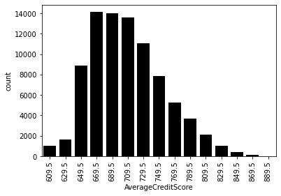

```python
#Plot credit score average
plt.xticks(rotation=90)
sb.countplot(data= analysis_df, x='AverageCreditScore', color= 'Black');
```

> Most borrowers have an average rating of between 649.5 to 749.5

```python
#Value_counts for ProsperScore
analysis_df['ProsperScore'].value_counts()
```

```
4.0     12595
6.0     12278
8.0     12053
7.0     10597
5.0      9813
3.0      7642
9.0      6911
2.0      5766
10.0     4750
11.0     1456
1.0       992
Name: ProsperScore, dtype: int64
```

we can see that there is rating of 11.0 which is contradicting with the definitions in the dictionary of this data set this maybe due to wrong typo error. Hence we will change the value of 11.0 to 10.0.

```python
# Define function to change scoring
def change_rating(row):
    if row['ProsperScore'] == 11.0:
        return 10.0
    else:
        return row['ProsperScore']
```

```python
#Replace 11.0 score with 10.0 score
analysis_df['ProsperScore'] = analysis_df.apply(change_rating, axis=1)
analysis_df['ProsperScore'].value_counts()
```

```
4.0     12595
6.0     12278
8.0     12053
7.0     10597
5.0      9813
3.0      7642
9.0      6911
10.0     6206
2.0      5766
1.0       992
Name: ProsperScore, dtype: int64
```

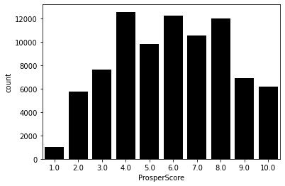

```python
#Plot the ProsperScore
sb.countplot(data= analysis_df, x='ProsperScore', color= 'Black');
```

> It is strange to see that on of the hieghest borrowers Propser Score are of low rating (4.0)

### Discuss the distribution(s) of your variable(s) of interest. Were there any unusual points? Did you need to perform any transformations?

> Prosper ratings was normally distributed. The disrubution of average credit scores was sckewed right. Also, the ProsperScore was strange to see that the rating 4.0 was the highest amongst the ratings. I did not beleive that any transformation is useful here.

### Of the features you investigated, were there any unusual distributions? Did you perform any operations on the data to tidy, adjust, or change the form of the data? If so, why did you do this?

> I thought that the credit score distribution should have been normally distributed. I have performed some operations to tidy the data where i dropped some null values and changed the data for LoanOriginationDate to datetime format. Also, changed the prosperscore 11.0 to 10.0 as the dictionary was stated that scores was from 1.0 to 10.0.

In the next steps we will remove the current status loans where they are not our focus in this analysis as we are investigating the outcomes of the loan which is completed or defaulted.

```python
#Get Value counts of LoanStatus
analysis_df['LoanStatus'].value_counts()
```

```
Current                   56576
Completed                 19664
Chargedoff                 5336
Defaulted                  1005
Past Due (1-15 days)        806
Past Due (31-60 days)       363
Past Due (61-90 days)       313
Past Due (91-120 days)      304
Past Due (16-30 days)       265
FinalPaymentInProgress      205
Past Due (>120 days)         16
Name: LoanStatus, dtype: int64
```

```python
# we will keep the defaulting, completed, and changedoff for our analysis.
loan_status_interest = (analysis_df['LoanStatus'] == 'Completed') | (analysis_df['LoanStatus'] == 'Defaulted') | (analysis_df['LoanStatus'] == 'Chargedoff')
analysis_df = analysis_df[loan_status_interest]
```

```python
# define function to set chargedoff as defaulted
def change_status(row):
    if row['LoanStatus'] == 'Chargedoff':
        return 'Defaulted'
    else:
        return row['LoanStatus']
```

```python
#Applying the function chage_to_defaulted to analysis_df
analysis_df['LoanStatus'] = analysis_df.apply(change_status, axis=1)
```

```python
#Check results
analysis_df['LoanStatus'].value_counts()
```

```
Completed    19664
Defaulted     6341
Name: LoanStatus, dtype: int64
```

## Bivariate Exploration

Let's see the correlation between numeric variables

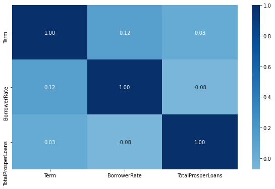

```python
#Plot Heat Map of Numeric variables
plt.figure(figsize = [10, 6])
variables = ['Term', 'BorrowerRate', 'TotalProsperLoans']
sb.heatmap(analysis_df[variables].corr(), annot = True, fmt = '.2f',
           cmap = 'Blues', center = 0)
plt.show()
```

> There is no strong correlation between variables in this data set.

Let's move to the categorical features.

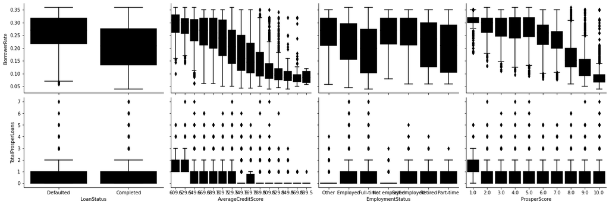

```python
variables2 = ['BorrowerRate', 'TotalProsperLoans']
categorical_variables = ['LoanStatus', 'AverageCreditScore', 'EmploymentStatus', 'ProsperScore']

#Define boxgrid function
def boxgrid(x, y, **kwargs):
    default_color = sb.color_palette()[0]
    sb.boxplot(x, y, color = 'Black')

plt.figure(figsize = [15, 15])
g = sb.PairGrid(data = analysis_df, y_vars = variables2, x_vars = categorical_variables,
                height = 3, aspect = 1.5)
g.map(boxgrid)
plt.show();
```

> On average the defaulted loans have higher borrower rates. while the average borrowers rate decreases when the credit score is higher as well as the prosperscore.

Next we will check what factors affect the outcome of the loanstatus (Defaulted or Completed)

loan status and Prosper rating:

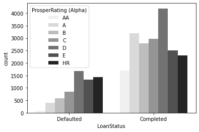

```python
#Plot Loan Status and Prosper Rating
sb.countplot(data= analysis_df, x='LoanStatus', hue='ProsperRating (Alpha)', palette='Greys')
```

> The Visual above shows that Rating 'D' is the most rating where borrowers have defaulted.

employment status and loan status:

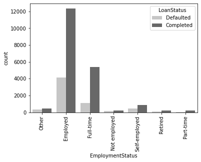

```python
#Plot Loan Status and Employment status
plt.xticks(rotation = 90)
sb.countplot(data= analysis_df, x='EmploymentStatus', hue='LoanStatus', palette='Greys');
```

> Visually it seems that burrowers with employment status 'Not Employed' and 'Self-employed are more likely to default on credit.

Term and loan status:

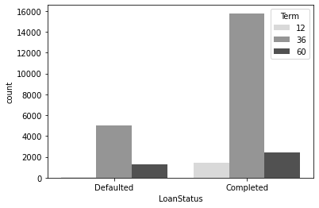

```python
#Plot Loan Status with Term
sb.countplot(data= analysis_df, x='LoanStatus', hue='Term', palette='Greys')
```

> Highest proportion of defaulted credits is among loans with Term of 60 months.

Credit Score with Loan Status

for this analyis we need to bin the credit scores for easy visualization

```python
#define function
def bin_creditscore(row):
    score = row['AverageCreditScore']
    if  score < 650:
        return 'up to 649'
    elif score < 700:
        return 'between 650 and 699'
    elif score < 750:
        return 'between 700 and 749'
    elif score < 800:
        return 'between 750 and 799'
    elif score < 850:
        return 'between 800 and 849'
    elif score < 900:
        return 'between 850 and 900'
```

```python
#apply function and check
analysis_df['CreditScoreBins'] = analysis_df.apply(bin_creditscore, axis=1)
analysis_df['CreditScoreBins'].value_counts()
```

```
between 700 and 749    9179
between 650 and 699    7491
up to 649              4423
between 750 and 799    3245
between 800 and 849    1573
between 850 and 900      94
Name: CreditScoreBins, dtype: int64
```

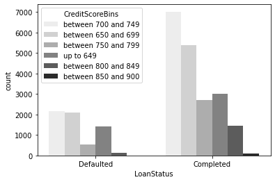

```python
#Plot loan status with credit score bins
sb.countplot(data= analysis_df, x='LoanStatus', hue='CreditScoreBins', palette='Greys')
```

Loan Status with Prospers Score:

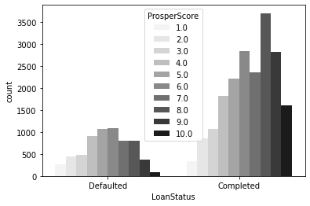

```python
#Plot loan status with ProsperScore
sb.countplot(data= analysis_df, x='LoanStatus', hue='ProsperScore', palette='Greys')
```

## Multivariate Exploration

Let's have a look on relationship between Term, borrow rate, employment, creditscore, properscore, listing category, total loans and Loan Status.

```python
analysis_df.columns
```

```
Index(['index', 'Term', 'LoanStatus', 'BorrowerRate', 'ProsperRating (Alpha)',
       'ListingCategory (numeric)', 'EmploymentStatus', 'TotalProsperLoans',
       'LoanOriginalAmount', 'LoanOriginationDate', 'CreditScoreRangeLower',
       'CreditScoreRangeUpper', 'ProsperScore', 'AverageCreditScore',
       'CreditScoreBins'],
      dtype='object')
```

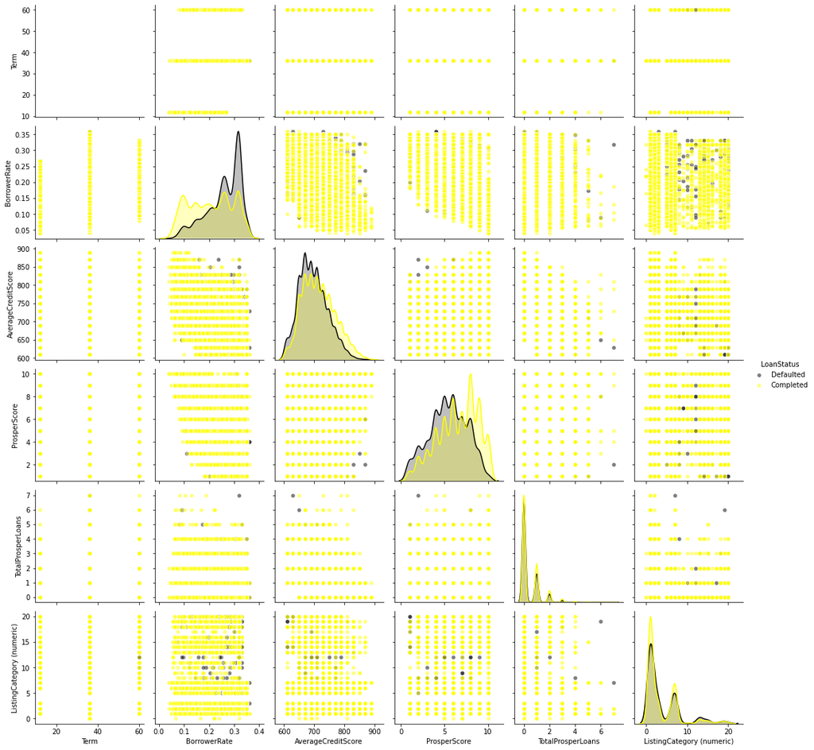

```python
#Plot Term, borrow rate, employment, creditscore, properscore Loan Status.
columns = [
    'Term', 'BorrowerRate', 'EmploymentStatus', 'AverageCreditScore',
    'ProsperScore', 'LoanStatus', 'ProsperRating (Alpha)', 'TotalProsperLoans', 'ListingCategory (numeric)'
       ]
sb.pairplot(analysis_df[columns], hue='LoanStatus',
                palette={'Defaulted': 'Black', 'Completed': 'Yellow'},
                plot_kws={'alpha': 0.5, 'edgecolor': 'white'})
```

> it appears that the listing category and borrow rate can be a good predictor for the loan status.

Let's have closer look at relationships between creditscore, prosperscore, employment and loan status

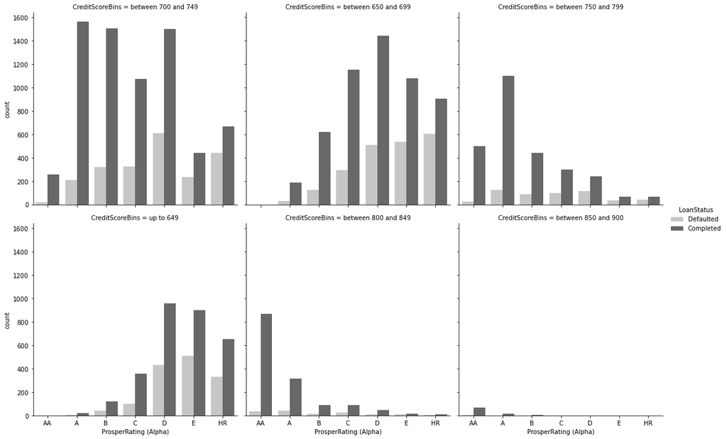

```python
# Plot ProsperRating with listingcategory
sb.catplot(x='ProsperRating (Alpha)', hue='LoanStatus', col='CreditScoreBins',
              data= analysis_df, kind='count', palette='Greys', col_wrap=3
             );
```

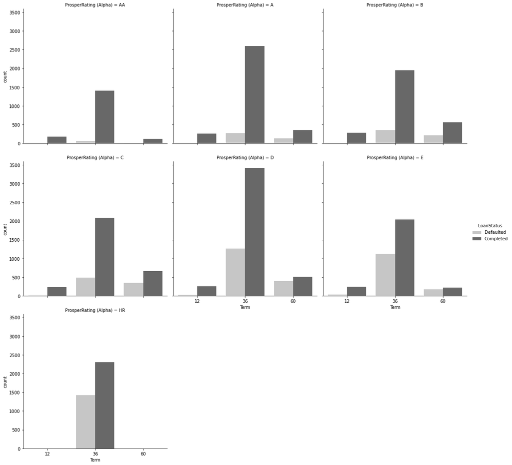

```python
# Plot Term, Category and the outcome
sb.catplot(x='Term', hue='LoanStatus', col='ProsperRating (Alpha)',
              data= analysis_df, kind='count', palette='Greys', col_wrap=3
             );
```

> There is no 12 months-term or 60 months-term loans given to the individuals with Rating HR.

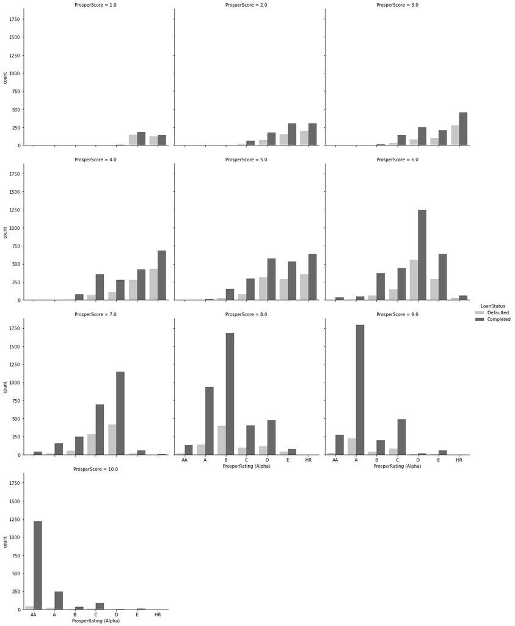

```python
#Plot ProsperRating, loan Statuns and ProsperScore
sb.catplot(x='ProsperRating (Alpha)', hue='LoanStatus', col='ProsperScore',
              data= analysis_df, kind='count', palette='Greys', col_wrap=3
             );
```

> Here we reaffirm that at prosperscore 6.0, there are more defaulters.

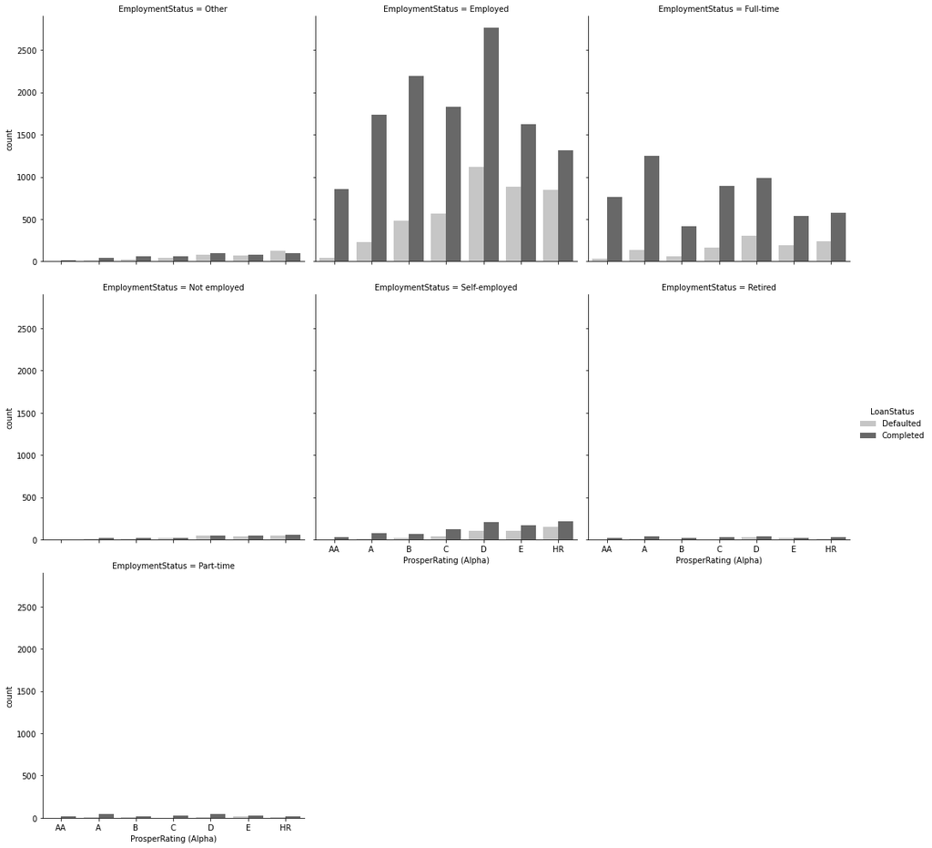

```python
#Plot ProsperRating, loan Statuns and employment
sb.catplot(x='ProsperRating (Alpha)', hue='LoanStatus', col='EmploymentStatus',
              data= analysis_df, kind='count', palette='Greys', col_wrap=3
             );
```

> here we see that the most proportions of defaulting are self-employed and not employed individuals.

### Talk about some of the relationships you observed in this part of the investigation. Were there features that strengthened each other in terms of looking at your feature(s) of interest?

> Most of the features strengthened the assumptions we have made and the loan status depends on Employment status.